# World Happiness Report

Happiness scored according to economic production, social support, etc.

- pandas API레퍼런스 : https://pandas.pydata.org/docs/reference/api/pandas.DataFrame.drop.html
- seaborn API레퍼런스 : http://seaborn.pydata.org/generated/seaborn.displot.html#seaborn.displot
1. 라이브러리, 데이터 불러오기
2. 분석의 목적과 변수 확인
3. 데이터 전체적으로 살펴보기
4. 데이터의 개별 속성 파악하기

## 1. 라이브러리, 데이터 불러오기

### 라이브러리 불러오기

### 데이터 불러오기

```
data15 = pd.read_csv('./data/word_happiness_report/2015.csv')
data16 = pd.read_csv('./data/word_happiness_report/2016.csv')
data17 = pd.read_csv('./data/word_happiness_report/2017.csv')
data18 = pd.read_csv('./data/word_happiness_report/2018.csv')
data19 = pd.read_csv('./data/word_happiness_report/2019.csv')
```

## 2. 분석의 목적과 변수 확인

- 행복에 기여하는 6가지 요소는 서로 어떤 상관관계를 가질까?
- 어떤 요소들이 행복을 증진하는데 기여를 할까?
- 전체적인 행복과 행복에 기여하는 6 가지 요소 각각에서 가장 높은 순위를 차지하는 국가 또는 지역은 어디일까?
- 2015 년과 2016 년, 2016 년과 2017 년 보고서 사이에 국가 순위 또는 점수가 어떻게 변경 되었는가? 행복이 크게 증가하거나 감소한 나라가 있는가?

## 3. 데이터 전체적으로 살펴보기

|  | Country | Region | Happiness Rank | Happiness Score | Standard Error | Economy (GDP per Capita) | Family | Health (Life Expectancy) | Freedom | Trust (Government Corruption) | Generosity | Dystopia Residual | Year |
| --- | --- | --- | --- | --- | --- | --- | --- | --- | --- | --- | --- | --- | --- |
| 0 | Switzerland | Western Europe | 1 | 7.587 | 0.03411 | 1.39651 | 1.34951 | 0.94143 | 0.66557 | 0.41978 | 0.29678 | 2.51738 | 2015 |
| 1 | Iceland | Western Europe | 2 | 7.561 | 0.04884 | 1.30232 | 1.40223 | 0.94784 | 0.62877 | 0.14145 | 0.43630 | 2.70201 | 2015 |
| 2 | Denmark | Western Europe | 3 | 7.527 | 0.03328 | 1.32548 | 1.36058 | 0.87464 | 0.64938 | 0.48357 | 0.34139 | 2.49204 | 2015 |
| 3 | Norway | Western Europe | 4 | 7.522 | 0.03880 | 1.45900 | 1.33095 | 0.88521 | 0.66973 | 0.36503 | 0.34699 | 2.46531 | 2015 |
| 4 | Canada | North America | 5 | 7.427 | 0.03553 | 1.32629 | 1.32261 | 0.90563 | 0.63297 | 0.32957 | 0.45811 | 2.45176 | 2015 |

|  | Country | Region | Happiness Rank | Happiness Score | Lower Confidence Interval | Upper Confidence Interval | Economy (GDP per Capita) | Family | Health (Life Expectancy) | Freedom | Trust (Government Corruption) | Generosity | Dystopia Residual | Year |
| --- | --- | --- | --- | --- | --- | --- | --- | --- | --- | --- | --- | --- | --- | --- |
| 0 | Denmark | Western Europe | 1 | 7.526 | 7.460 | 7.592 | 1.44178 | 1.16374 | 0.79504 | 0.57941 | 0.44453 | 0.36171 | 2.73939 | 2016 |
| 1 | Switzerland | Western Europe | 2 | 7.509 | 7.428 | 7.590 | 1.52733 | 1.14524 | 0.86303 | 0.58557 | 0.41203 | 0.28083 | 2.69463 | 2016 |
| 2 | Iceland | Western Europe | 3 | 7.501 | 7.333 | 7.669 | 1.42666 | 1.18326 | 0.86733 | 0.56624 | 0.14975 | 0.47678 | 2.83137 | 2016 |
| 3 | Norway | Western Europe | 4 | 7.498 | 7.421 | 7.575 | 1.57744 | 1.12690 | 0.79579 | 0.59609 | 0.35776 | 0.37895 | 2.66465 | 2016 |
| 4 | Finland | Western Europe | 5 | 7.413 | 7.351 | 7.475 | 1.40598 | 1.13464 | 0.81091 | 0.57104 | 0.41004 | 0.25492 | 2.82596 | 2016 |

|  | Country | Happiness.Rank | Happiness.Score | Whisker.high | Whisker.low | Economy..GDP.per.Capita. | Family | Health..Life.Expectancy. | Freedom | Generosity | Trust..Government.Corruption. | Dystopia.Residual | Year |
| --- | --- | --- | --- | --- | --- | --- | --- | --- | --- | --- | --- | --- | --- |
| 0 | Norway | 1 | 7.537 | 7.594445 | 7.479556 | 1.616463 | 1.533524 | 0.796667 | 0.635423 | 0.362012 | 0.315964 | 2.277027 | 2017 |
| 1 | Denmark | 2 | 7.522 | 7.581728 | 7.462272 | 1.482383 | 1.551122 | 0.792566 | 0.626007 | 0.355280 | 0.400770 | 2.313707 | 2017 |
| 2 | Iceland | 3 | 7.504 | 7.622030 | 7.385970 | 1.480633 | 1.610574 | 0.833552 | 0.627163 | 0.475540 | 0.153527 | 2.322715 | 2017 |
| 3 | Switzerland | 4 | 7.494 | 7.561772 | 7.426227 | 1.564980 | 1.516912 | 0.858131 | 0.620071 | 0.290549 | 0.367007 | 2.276716 | 2017 |
| 4 | Finland | 5 | 7.469 | 7.527542 | 7.410458 | 1.443572 | 1.540247 | 0.809158 | 0.617951 | 0.245483 | 0.382612 | 2.430182 | 2017 |

|  | Overall rank | Country or region | Score | GDP per capita | Social support | Healthy life expectancy | Freedom to make life choices | Generosity | Perceptions of corruption | Year |
| --- | --- | --- | --- | --- | --- | --- | --- | --- | --- | --- |
| 0 | 1 | Finland | 7.632 | 1.305 | 1.592 | 0.874 | 0.681 | 0.202 | 0.393 | 2018 |
| 1 | 2 | Norway | 7.594 | 1.456 | 1.582 | 0.861 | 0.686 | 0.286 | 0.340 | 2018 |
| 2 | 3 | Denmark | 7.555 | 1.351 | 1.590 | 0.868 | 0.683 | 0.284 | 0.408 | 2018 |
| 3 | 4 | Iceland | 7.495 | 1.343 | 1.644 | 0.914 | 0.677 | 0.353 | 0.138 | 2018 |
| 4 | 5 | Switzerland | 7.487 | 1.420 | 1.549 | 0.927 | 0.660 | 0.256 | 0.357 | 2018 |

|  | Overall rank | Country or region | Score | GDP per capita | Social support | Healthy life expectancy | Freedom to make life choices | Generosity | Perceptions of corruption | Year |
| --- | --- | --- | --- | --- | --- | --- | --- | --- | --- | --- |
| 0 | 1 | Finland | 7.769 | 1.340 | 1.587 | 0.986 | 0.596 | 0.153 | 0.393 | 2019 |
| 1 | 2 | Denmark | 7.600 | 1.383 | 1.573 | 0.996 | 0.592 | 0.252 | 0.410 | 2019 |
| 2 | 3 | Norway | 7.554 | 1.488 | 1.582 | 1.028 | 0.603 | 0.271 | 0.341 | 2019 |
| 3 | 4 | Iceland | 7.494 | 1.380 | 1.624 | 1.026 | 0.591 | 0.354 | 0.118 | 2019 |
| 4 | 5 | Netherlands | 7.488 | 1.396 | 1.522 | 0.999 | 0.557 | 0.322 | 0.298 | 2019 |

같은 의미이지만 다른 이름을 갖고 있는 column들의 이름을 통일해준다.

15~19년도 데이터를 병합해준다.

모든 연도에서 공통적으로 갖고 있지 않은 column들을 제거해준다.

|  | Country | Happiness Rank | Happiness Score | GDP per capita | Family | Healthy life expectancy | Freedom | Perceptions of corruption | Generosity | Year | Region | Continent |
| --- | --- | --- | --- | --- | --- | --- | --- | --- | --- | --- | --- | --- |
| 0 | Switzerland | 1 | 7.587 | 1.396510 | 1.349510 | 0.941430 | 0.665570 | 0.419780 | 0.296780 | 2015 | Western Europe | Europe |
| 1 | Switzerland | 2 | 7.509 | 1.527330 | 1.145240 | 0.863030 | 0.585570 | 0.412030 | 0.280830 | 2016 | Western Europe | Europe |
| 2 | Switzerland | 4 | 7.494 | 1.564980 | 1.516912 | 0.858131 | 0.620071 | 0.367007 | 0.290549 | 2017 | Western Europe | Europe |
| 3 | Switzerland | 5 | 7.487 | 1.420000 | 1.549000 | 0.927000 | 0.660000 | 0.357000 | 0.256000 | 2018 | Western Europe | Europe |
| 4 | Switzerland | 6 | 7.480 | 1.452000 | 1.526000 | 1.052000 | 0.572000 | 0.343000 | 0.263000 | 2019 | Western Europe | Europe |
| ... | ... | ... | ... | ... | ... | ... | ... | ... | ... | ... | ... | ... |
| 752 | Togo | 158 | 2.839 | 0.208680 | 0.139950 | 0.284430 | 0.364530 | 0.107310 | 0.166810 | 2015 | Sub-Saharan Africa | Africa |
| 753 | Togo | 155 | 3.303 | 0.281230 | 0.000000 | 0.248110 | 0.346780 | 0.115870 | 0.175170 | 2016 | Sub-Saharan Africa | Africa |
| 754 | Togo | 150 | 3.495 | 0.305445 | 0.431883 | 0.247106 | 0.380426 | 0.095665 | 0.196896 | 2017 | Sub-Saharan Africa | Africa |
| 755 | Togo | 139 | 3.999 | 0.259000 | 0.474000 | 0.253000 | 0.434000 | 0.101000 | 0.158000 | 2018 | Sub-Saharan Africa | Africa |
| 756 | Togo | 139 | 4.085 | 0.275000 | 0.572000 | 0.410000 | 0.293000 | 0.085000 | 0.177000 | 2019 | Sub-Saharan Africa | Africa |

757 rows × 12 columns

데이터가 결측치를 갖는지 확인해보자.

```
Country                      0
Happiness Rank               0
Happiness Score              0
GDP per capita               0
Family                       0
Healthy life expectancy      0
Freedom                      0
Perceptions of corruption    1
Generosity                   0
Year                         0
Region                       0
Continent                    0
dtype: int64
```

Perceptions of corruption에 결측치가 하나 존재하지만, 미미한 정도의 수준이므로 넘어가도록 하자.

- 행복에 기여하는 6가지 요소는 서로 어떤 상관관계를 가질까?
- 어떤 요소들이 행복을 증진하는데 기여를 할까?
- 전체적인 행복과 행복에 기여하는 6 가지 요소 각각에서 가장 높은 순위를 차지하는 국가 또는 지역은 어디일까?
- 2015 년과 2016 년, 2016 년과 2017 년 보고서 사이에 국가 순위 또는 점수가 어떻게 변경 되었는가? 행복이 크게 증가하거나 감소한 나라가 있는가?

각 column에 대한 설명은 다음과 같다.

- Country or Region
  - 연도별 국가 순위를 보고 행복이 크게 증가하거나 감소한 나라가 있는지 살펴볼 수 있겠다.
- Happiness Rank : Rank of the country based on the Happiness Score.
  - Happiness Score와 같이 취급해도 될 것이다.
- Happiness Score : A metric measured by asking the sampled people the question: "How would you rate your happiness on a scale of 0 to 10 where 10 is the happiest."
  - Happiness Rank와 같이 취급해도 될 것이다.
- Economy : real GDP per capita
  - 경제적으로 얼마나 부유한지를 의미한다.
- Family : social support
  - 가족 수를 의미한다.
- Health : healthy life expectancy
  - 건강한 삶에 대한 기대 정도.
- Freedom : freedom to make life choices
  - 인생에 있어 선택에 대한 자유.
- Trust : perceptions of corruption
  - 국가 부패에 대한 인식
- Generosity : perceptions of generosity
  - 관대함에 대한 인식. 행복할수록 관대한 성격의 사람이 많은 것일까? 각 국가별 문화에도 영향을 줄 것 같다.
- Dystopia : each country is compared against a hypothetical nation that represents the lowest national averages for each key variable and is, along with residual error, used as a regression benchmark
  - 이 부분은 어떤 연도에는 측정되지 않아 삭제했다.

**상관계수에 대하여**

- -1에 가까운 값이 얻어지면 : 누가 봐도 매우 강력한 음(-)의 상관. 오히려 너무 확고하기 때문에 사회과학 데이터일 경우 데이터를 조작한 게 아닌가 의심할 정도이다. 물론 이건 사회과학 얘기고 순수학문에 가까운 분야일수록 요구되는 상관관계는 높은 편.
- -0.5 정도의 값이 얻어지면 : 강력한 음(-)의 상관. 연구자는 변인 x 가 증가하면 변인 y 가 감소한다고 자신 있게 말할 수 있다.
- -0.2 정도의 값이 얻어지면 : 음(-)의 상관이긴 한데 너무 약해서 모호하다. 상관관계가 없다고는 할 수 없지만 좀 더 의심해 봐야 한다.
- 0 정도의 값이 얻어지면 : 대부분의 경우, 상관관계가 있을거라고 간주되지 않는다. 다른 후속 연구들을 통해 뒤집어질지는 모르지만 일단은 회의적이다. 하지만 무조건적으로 그런건 아니라 2차 방정식 그래프와 비슷한 모양이 될 경우 상관관계는 있으나 상관계수는 0에 가깝게 나온다.
- 0.2 정도의 값이 얻어지면 : 너무 약해서 의심스러운 양(+)의 상관. 이것만으로는 상관관계에 대해 아주 장담할 수는 없다. 하지만 사회과학에선 매우 큰 상관관계가 있는 것으로 간주한다.
- 0.5 정도의 값이 얻어지면 : 강력한 양(+)의 상관. 변인 x 가 증가하면 변인 y 가 증가한다는 주장은 이제 통계적으로 지지받고 있다.
- 1에 가까운 값이 얻어지면 : 이상할 정도로 강력한 양(+)의 상관. 위와 마찬가지로, 이렇게까지 확고한 상관관계는 오히려 쉽게 찾아보기 어렵다.

일반적으로

r이 -1.0과 -0.7 사이이면, 강한 음적 선형관계,  
r이 -0.7과 -0.3 사이이면, 뚜렷한 음적 선형관계,  
r이 -0.3과 -0.1 사이이면, 약한 음적 선형관계,  
r이 -0.1과 +0.1 사이이면, 거의 무시될 수 있는 선형관계,  
r이 +0.1과 +0.3 사이이면, 약한 양적 선형관계,  
r이 +0.3과 +0.7 사이이면, 뚜렷한 양적 선형관계,  
r이 +0.7과 +1.0 사이이면, 강한 양적 선형관계  
로 해석한다.

**상관계수 확인해보기**

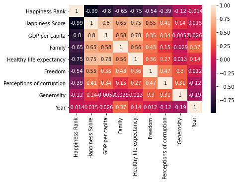

|  | Happiness Rank | Happiness Score | GDP per capita | Family | Healthy life expectancy | Freedom | Perceptions of corruption | Generosity | Year |
| --- | --- | --- | --- | --- | --- | --- | --- | --- | --- |
| Happiness Rank | 1.000000 | -0.992205 | -0.802026 | -0.646295 | -0.748683 | -0.538112 | -0.387597 | -0.119463 | -0.014137 |
| Happiness Score | -0.992205 | 1.000000 | 0.797339 | 0.650595 | 0.747745 | 0.550108 | 0.412705 | 0.139592 | 0.014665 |
| GDP per capita | -0.802026 | 0.797339 | 1.000000 | 0.575385 | 0.779341 | 0.353443 | 0.341236 | -0.005723 | 0.025971 |
| Family | -0.646295 | 0.650595 | 0.575385 | 1.000000 | 0.562217 | 0.427273 | 0.148739 | -0.029177 | 0.372966 |
| Healthy life expectancy | -0.748683 | 0.747745 | 0.779341 | 0.562217 | 1.000000 | 0.355520 | 0.274275 | 0.013498 | 0.136038 |
| Freedom | -0.538112 | 0.550108 | 0.353443 | 0.427273 | 0.355520 | 1.000000 | 0.465758 | 0.302158 | 0.011839 |
| Perceptions of corruption | -0.387597 | 0.412705 | 0.341236 | 0.148739 | 0.274275 | 0.465758 | 1.000000 | 0.310106 | -0.120543 |
| Generosity | -0.119463 | 0.139592 | -0.005723 | -0.029177 | 0.013498 | 0.302158 | 0.310106 | 1.000000 | -0.190227 |
| Year | -0.014137 | 0.014665 | 0.025971 | 0.372966 | 0.136038 | 0.011839 | -0.120543 | -0.190227 | 1.000000 |

이제 깔끔하게 2015~20019년도를 합쳐서 column간의 상관관계를 파악할 수 있다.  
-1, 1에 가까운 이상할 정도로 강력한 상관관계를 제외하고, 어떤 요소들이 행복에 기여하는지 알아보자. Happiness Score가 높을수록 Happiness Rank는 낮아진다. Happiness Score와 Rank는 같은 의미를 갖는 column이기 때문에, 여기서는 "행복"의 기준을 Happiness Score을 기준으로 하겠다.

**상관계수에 따른 가설 세우기**

- Happiness Score : 행복 점수
  - GDP per capita
    - 0.79의 상관관계를 갖는다.
    - GDP per capita가 높을수록, 즉 경제적으로 잘 살수록 행복지수가 높을 것이다.
  - Family
    - 0.65의 상관관계를 갖는다.
    - 가족이 많을수록 행복지수가 높을 것이다.
  - Healthy life expenctancy
    - 0.74의 상관관계를 갖는다.
    - 건강한 삶에 대한 기대 정도가 높을수록 행복지수가 높을 것이다.
  - Freedom
    - 0.55의 상관관계를 갖는다.
    - 자유로울수록 행복지수가 높을 것이다.

Happiness Score외의 요소들이 서로 갖는 상관관계에 대해 알아보자.

# 4. 데이터의 개별 속성 파악하기

**분석 목적 검토**

- 행복에 기여하는 6가지 요소는 서로 어떤 상관관계를 가질까?
- 어떤 요소들이 행복을 증진하는데 기여를 할까?

### 1.1 Happiness Score & GDP per capita : 0.79

GDP per capita가 높을수록, 즉 경제적으로 잘 살수록 행복지수가 높아짐을 알 수 있다.

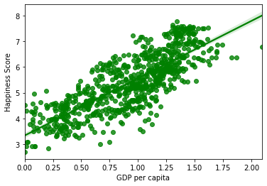

[interactive chart not shown]

### 1.2 Happiness Score & Family : 0.65

가족이 많을수록, 행복지수가 높아짐을 알 수 있다.

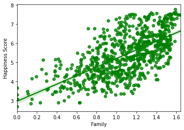

[interactive chart not shown]

### 1.3 Happiness Score & Healthy life expectancy : 0.74

건강한 삶에 대한 기대 정도가 높을수록 행복지수가 높아짐을 알 수 있다.

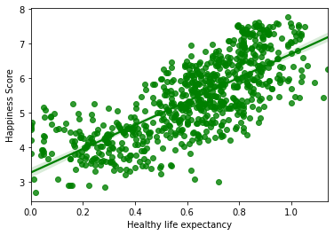

[interactive chart not shown]

### 1.4 Happiness Score & Freedom : 0.55

인생에 있어 선택의 자유를 많이 느낄수록 행복지수가 높아짐을 알 수 있다.

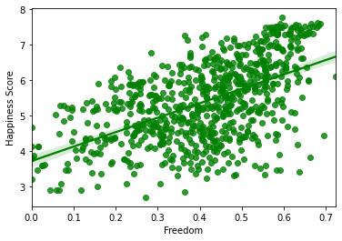

[interactive chart not shown]

1인당 GDP 지수가 높을수록, 즉 경제적으로 부유할수록 가족이 많음을 알 수 있다.

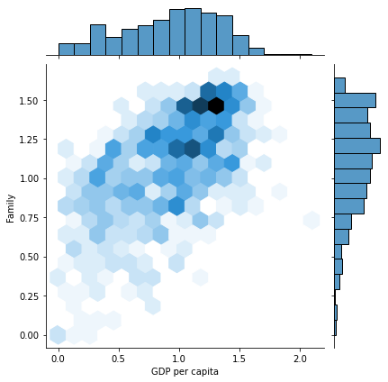

### 2.2 GDP per capita & Healthy life expectancy : 0.78

1인당 GDP 지수가 높을수록, 즉 경제적으로 부유할수록 건강한 삶에 대한 기대 정도가 높음을 알 수 있다.

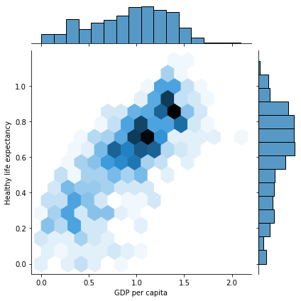

### 3.1 Freedom & Family : 0.42

인생에 있어 선택에 대한 자유를 많이 느낄수록 가족이 많음을 알 수 있다.

[figure not shown]

### 3.2 Freedom & Perception of corruption : 0.46

[figure not shown]

[figure not shown]

**분석 목적 검토**

- 전체적인 행복과 행복에 기여하는 6 가지 요소 각각에서 가장 높은 순위를 차지하는 국가 또는 지역은 어디일까?

[interactive chart not shown]

**분석 목적 검토**  
2015 년과 2016 년, 2016 년과 2017 년 보고서 사이에 국가 순위 또는 점수가 어떻게 변경 되었는가? 행복이 크게 증가하거나 감소한 나라가 있는가?

[interactive chart not shown]